# Fertility prediction with linear regression

Mario Farrapo

2026-02-21

In this project, we use the **`swiss`** dataset from base R to study the relationship between several socioeconomic variables across Swiss provinces and fertility levels, with the goal of building a multivariate model.

```r
library(tidyverse)
library(GGally)
library(performance)
```

```r
data("swiss")
head(swiss)
```

```
##              Fertility Agriculture Examination Education Catholic
## Courtelary        80.2        17.0          15        12     9.96
## Delemont          83.1        45.1           6         9    84.84
## Franches-Mnt      92.5        39.7           5         5    93.40
## Moutier           85.8        36.5          12         7    33.77
## Neuveville        76.9        43.5          17        15     5.16
## Porrentruy        76.1        35.3           9         7    90.57
##              Infant.Mortality
## Courtelary               22.2
## Delemont                 22.2
## Franches-Mnt             20.2
## Moutier                  20.3
## Neuveville               20.6
## Porrentruy               26.6
```

Each row corresponds to a different province, and multiple socioeconomic variables are available for each region.

## Exploration

We aim to build a model to predict fertility levels; however, we do not yet know how the data are distributed or how the variables relate to one another. Therefore, we begin with an exploratory data analysis using the `GGally::ggpairs()` function.

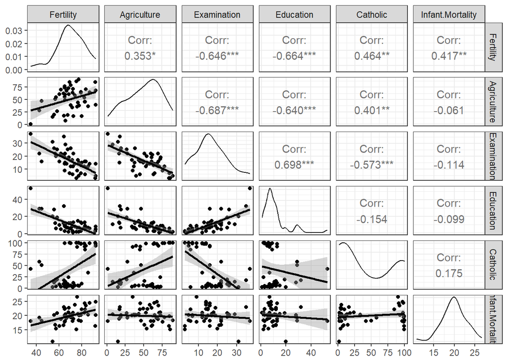

```r
ggpairs(swiss,
        lower = list(continuous = "smooth")) +
  theme_bw()
```

```r
shapiro.test(swiss$Fertility)
```

```
##
##  Shapiro-Wilk normality test
##
## data:  swiss$Fertility
## W = 0.97307, p-value = 0.3449
```

We observe that Fertility has an approximately normal distribution and is correlated with all other variables in a roughly linear manner. The Shapiro–Wilk test confirms the normality of Fertility. Based on these results, we proceed with a multivariate linear regression model.

## Modeling

```r
lm <- lm(Fertility ~ Agriculture + Examination + Education + Catholic + Infant.Mortality, data = swiss)

summary(lm)
```

```
##
## Call:
## lm(formula = Fertility ~ Agriculture + Examination + Education +
##     Catholic + Infant.Mortality, data = swiss)
##
## Residuals:
##      Min       1Q   Median       3Q      Max
## -15.2743  -5.2617   0.5032   4.1198  15.3213
##
## Coefficients:
##                  Estimate Std. Error t value Pr(>|t|)
## (Intercept)      66.91518   10.70604   6.250 1.91e-07 ***
## Agriculture      -0.17211    0.07030  -2.448  0.01873 *
## Examination      -0.25801    0.25388  -1.016  0.31546
## Education        -0.87094    0.18303  -4.758 2.43e-05 ***
## Catholic          0.10412    0.03526   2.953  0.00519 **
## Infant.Mortality  1.07705    0.38172   2.822  0.00734 **
## ---
## Signif. codes:  0 '***' 0.001 '**' 0.01 '*' 0.05 '.' 0.1 ' ' 1
##
## Residual standard error: 7.165 on 41 degrees of freedom
## Multiple R-squared:  0.7067, Adjusted R-squared:  0.671
## F-statistic: 19.76 on 5 and 41 DF,  p-value: 5.594e-10
```

At this stage, we observe that the model shows strong apparent statistical performance, with an adjusted R² of 0.67 and a p-value of 5.594e−10. However, the variable Examination does not provide a significant contribution to the model. We therefore remove it and compare the two models.

```r
reduced_lm <- lm(Fertility ~ Agriculture + Education + Catholic + Infant.Mortality, data = swiss)

compare_performance(reduced_lm, lm)
```

```
## # Comparison of Model Performance Indices
##
## Name       | Model | AIC (weights) | AICc (weights) | BIC (weights) |    R2
## ---------------------------------------------------------------------------
## reduced_lm |    lm | 325.2 (0.602) |  327.3 (0.690) | 336.3 (0.793) | 0.699
## lm         |    lm | 326.1 (0.398) |  328.9 (0.310) | 339.0 (0.207) | 0.707
##
## Name       | R2 (adj.) |  RMSE | Sigma
## --------------------------------------
## reduced_lm |     0.671 | 6.776 | 7.168
## lm         |     0.671 | 6.692 | 7.165
```

The comparison shows that the full model (`lm`) fits the data very similarly to the reduced model (`reduced_lm`). However, the model weights indicate that the reduced model has a much higher probability of being the best model among those tested. In addition, the adjusted R² is identical for both models. Considering the principle of parsimony, we retain the reduced model.

## Diagnostics

Next, we perform model diagnostics to assess whether the assumptions of the linear regression model are satisfied.

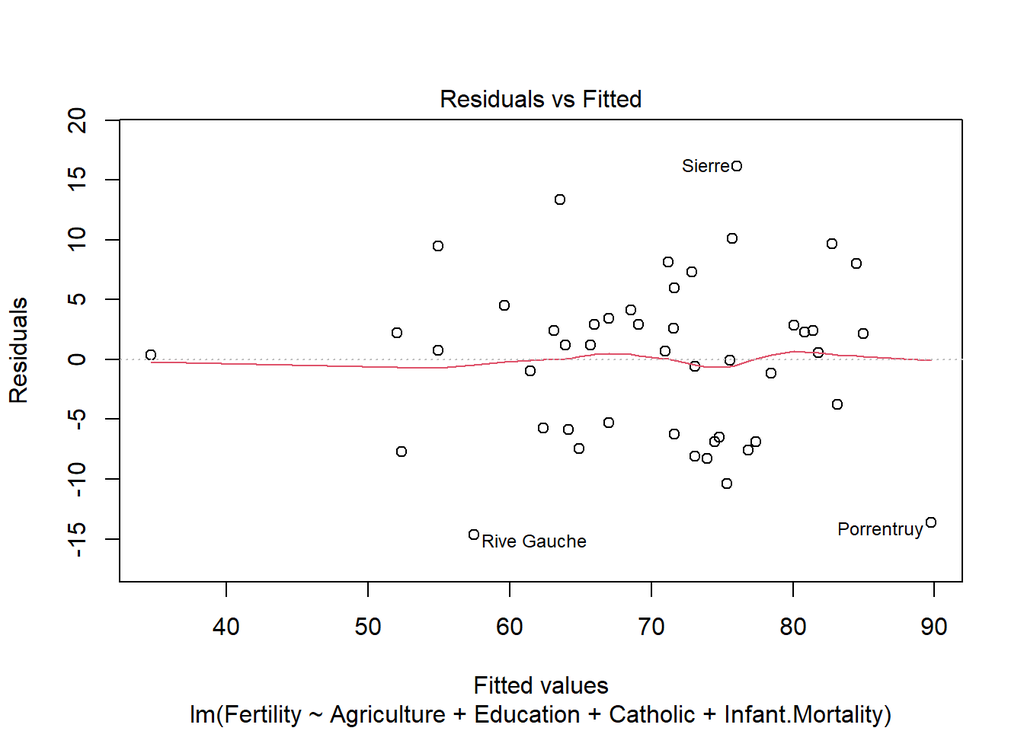

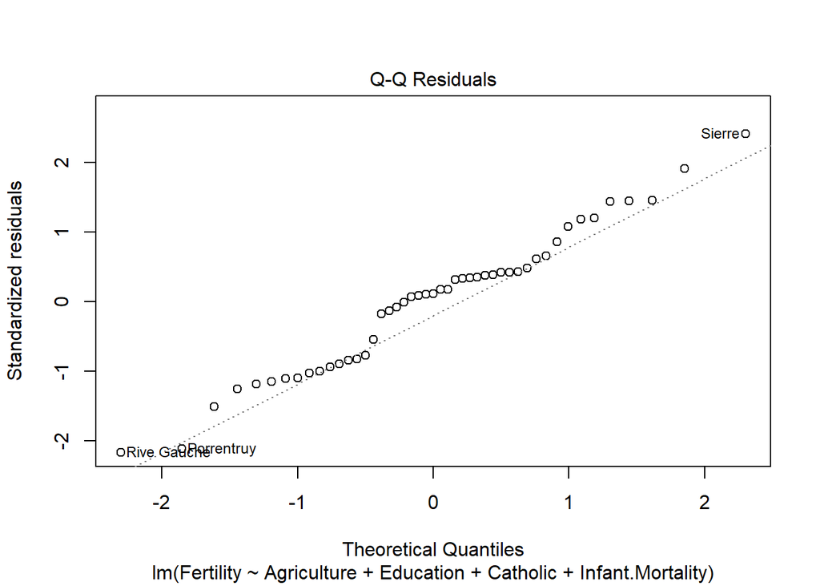

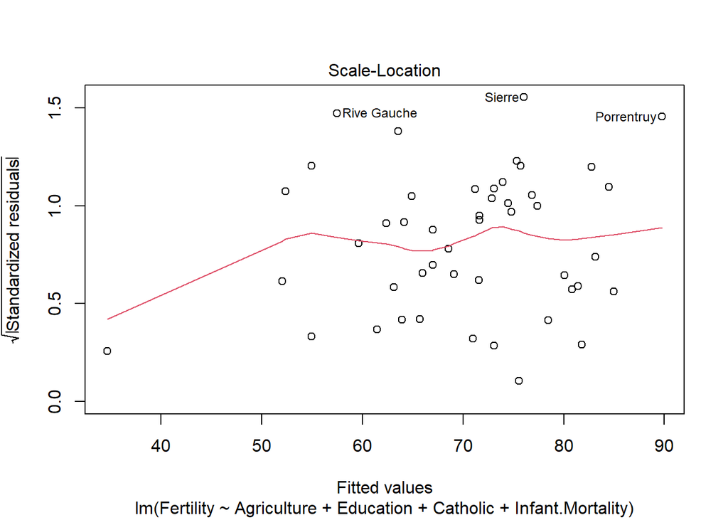

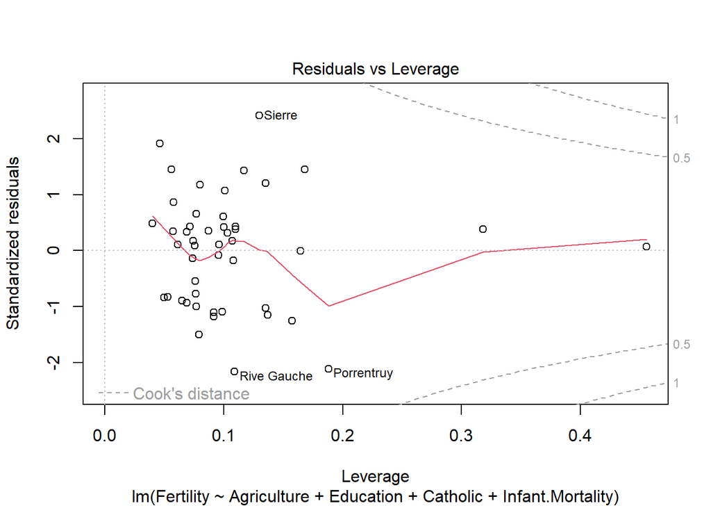

```r
plot(reduced_lm)
```

```r
check_normality(reduced_lm)
```

```
## OK: residuals appear as normally distributed (p = 0.461).
```

```r
check_collinearity(reduced_lm)
```

```
## # Check for Multicollinearity
##
## Low Correlation
##
##              Term  VIF   VIF 95% CI adj. VIF Tolerance Tolerance 95% CI
##       Agriculture 2.15 [1.57, 3.30]     1.47      0.47     [0.30, 0.64]
##         Education 1.82 [1.37, 2.78]     1.35      0.55     [0.36, 0.73]
##          Catholic 1.30 [1.08, 2.09]     1.14      0.77     [0.48, 0.92]
##  Infant.Mortality 1.11 [1.01, 2.65]     1.05      0.90     [0.38, 0.99]
```

```r
check_autocorrelation(reduced_lm)
check_heteroscedasticity(reduced_lm)
```

[output not shown]

```
## OK: Error variance appears to be homoscedastic (p = 0.494).
```

## Visualization

Finally, we visualize the final model.

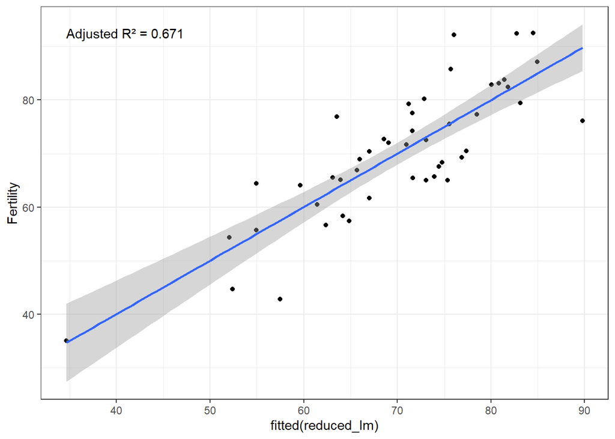

```r
ggplot(swiss, aes(x = fitted(reduced_lm), y = Fertility)) +
  geom_point() +
  geom_smooth(method = "lm") +
  annotate("text",
           x = min(fitted(reduced_lm)),
           y = max(swiss$Fertility),
           label = paste0(
                  "Adjusted R² = ",
                  round(summary(reduced_lm)$adj.r.squared, 3)),
            hjust = 0) +
  theme_bw()
```